# 1R Mammals Report

**Name:** Austin Sampson

**eMail:** aws9t5@mst.edu

**Course:** CS 5402

**Date:** 02-14-2020

## Concept Description:

Train a system from existing data to classify animals as either mammal or non-mammal

## Example Description:

**animal.name**

nominal attribute name of the animal or species

**hair**

Nominal boolean attribute that displays output as: True False

**feathers**

Nominal boolean attribute that displays output as: True False

**eggs**

Nominal boolean attribute that displays output as: True False

**milk**

Nominal boolean attribute that displays output as: True False

**airborne**

Nominal boolean attribute that displays output as: True False

**aquatic**

Nominal boolean attribute that displays output as: True False

**preditor**

Nominal boolean attribute that displays output as: True False

**toothed**

Nominal boolean attribute that displays output as: True False

**backbone**

Nominal boolean attribute that displays output as: True False

**breathes**

Nominal boolean attribute that displays output as: True False

**venomous**

Nominal boolean attribute that displays output as: True False

**fins**

Nominal boolean attribute that displays output as: True False

**legs**

Ratio Lable displaying the number of legs. null value or 0 indicates the absince of legs.

**tail**

Nominal boolean attribute that displays output as: True False

**domestic**

Nominal boolean attribute that displays output as: True False

**catsize**

Nominal boolean attribute that displays output as: True False

**gestation**

**type**

Nominal, Main classificationn variable for this data set. Output displayed as: mammal fish arthropod bird insect amphibian reptile

## Data Import and Wrangling:

Importing test and training data

```r
#import main file
train <- read.csv("animal-taxonomy-train.csv")
test <- read.csv("animal-taxonomy-test.csv")
```

We remove the name attribute to prevent the moddel from overfitting by training for name attributes

```r
#remove the name attribute from the test and training data
train$legs=NULL
train$animal.name=NULL
train$animal.name=NULL
test$legs=NULL
test$animal.name=NULL
train$gestation=NULL
```

## Mining and Analytics:

**Naive Bayes Classifiers**

Traing the Confusion Matrix for bayes classification

```r
train.nb <- naiveBayes(type ~ ., data=train)
train.nb
```

```
##
## Naive Bayes Classifier for Discrete Predictors
##
## Call:
## naiveBayes.default(x = X, y = Y, laplace = laplace)
##
## A-priori probabilities:
## Y
##  amphibian  arthropod       bird       fish     insect     mammal    reptile
## 0.04395604 0.10989011 0.18681319 0.13186813 0.08791209 0.38461538 0.05494505
##
## Conditional probabilities:
##            hair
## Y                FALSE       TRUE
##   amphibian 1.00000000 0.00000000
##   arthropod 1.00000000 0.00000000
##   bird      1.00000000 0.00000000
##   fish      1.00000000 0.00000000
##   insect    0.50000000 0.50000000
##   mammal    0.02857143 0.97142857
##   reptile   1.00000000 0.00000000
##
##            feathers
## Y           FALSE TRUE
##   amphibian     1    0
##   arthropod     1    0
##   bird          0    1
##   fish          1    0
##   insect        1    0
##   mammal        1    0
##   reptile       1    0
##
##            eggs
## Y           FALSE TRUE
##   amphibian   0.0  1.0
##   arthropod   0.1  0.9
##   bird        0.0  1.0
##   fish        0.0  1.0
##   insect      0.0  1.0
##   mammal      1.0  0.0
```

[output cut: 106 more lines]

```
##   bird      0.94117647 0.05882353
##   fish      0.91666667 0.08333333
##   insect    0.87500000 0.12500000
##   mammal    0.77142857 0.22857143
##   reptile   1.00000000 0.00000000
##
##            catsize
## Y               FALSE      TRUE
##   amphibian 1.0000000 0.0000000
##   arthropod 0.9000000 0.1000000
##   bird      0.7058824 0.2941176
##   fish      0.7500000 0.2500000
##   insect    1.0000000 0.0000000
##   mammal    0.2571429 0.7428571
##   reptile   0.8000000 0.2000000
```

**ID3** To train the ID3 Classifier I untailzied the rpart package and their graphing tools

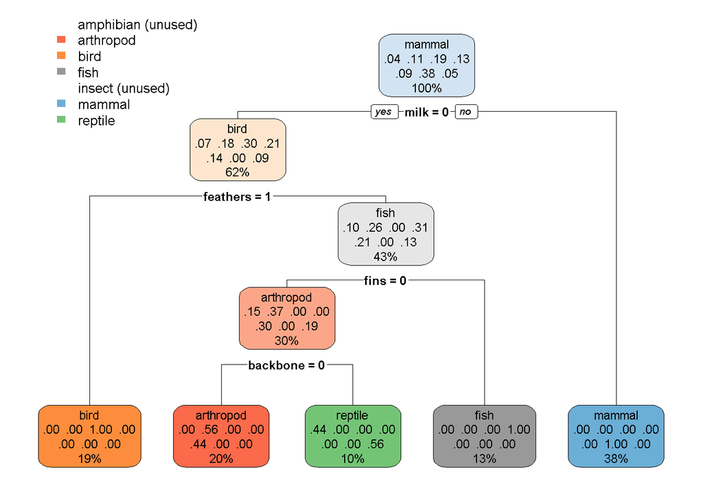

```r
#train the id3 model using the rpart library
model.id3 <-rpart(type ~., data = train)
rpart.plot(model.id3)
```

## Evaluation:

**ID3** Calculating the Confusion matrix for ID3 decision tree classification Using the model create a prediction for the dataset and compare it to the actual

```r
#predict classification using id3 model
pred.id3 <- predict(model.id3, test,type="class")
#print the generated classification decision tree

#Calculated the confusion matrix based off the prediction
pred.id3 <- droplevels(pred.id3)
confusionMatrix(pred.id3,test$type)
```

```
## Confusion Matrix and Statistics
##
##           Reference
## Prediction bird fish mammal
##     bird      3    0      0
##     fish      0    1      0
##     mammal    0    0      6
##
## Overall Statistics
##
##                Accuracy : 1
##                  95% CI : (0.6915, 1)
##     No Information Rate : 0.6
##     P-Value [Acc > NIR] : 0.006047
##
##                   Kappa : 1
##
##  Mcnemar's Test P-Value : NA
##
## Statistics by Class:
##
##                      Class: bird Class: fish Class: mammal
## Sensitivity                  1.0         1.0           1.0
## Specificity                  1.0         1.0           1.0
## Pos Pred Value               1.0         1.0           1.0
## Neg Pred Value               1.0         1.0           1.0
## Prevalence                   0.3         0.1           0.6
## Detection Rate               0.3         0.1           0.6
## Detection Prevalence         0.3         0.1           0.6
## Balanced Accuracy            1.0         1.0           1.0
```

```r
m_predictions <- predict(train.nb, test)

#table(m_predictions);
#table(test);


m_predictions <- droplevels(m_predictions)
cfm <- confusionMatrix(m_predictions, test$type)
cfm
```

```
## Confusion Matrix and Statistics
##
##           Reference
## Prediction bird fish mammal
##     bird      3    0      0
##     fish      0    1      0
##     mammal    0    0      6
##
## Overall Statistics
##
##                Accuracy : 1
##                  95% CI : (0.6915, 1)
##     No Information Rate : 0.6
##     P-Value [Acc > NIR] : 0.006047
##
##                   Kappa : 1
##
##  Mcnemar's Test P-Value : NA
##
## Statistics by Class:
##
##                      Class: bird Class: fish Class: mammal
## Sensitivity                  1.0         1.0           1.0
## Specificity                  1.0         1.0           1.0
## Pos Pred Value               1.0         1.0           1.0
## Neg Pred Value               1.0         1.0           1.0
## Prevalence                   0.3         0.1           0.6
## Detection Rate               0.3         0.1           0.6
## Detection Prevalence         0.3         0.1           0.6
## Balanced Accuracy            1.0         1.0           1.0
```

## References:

https://www.rdocumentation.org/packages/caret/versions/3.45/topics/confusionMatrix https://www.rdocumentation.org/packages/utils/versions/3.6.2/topics/data http://www.learnbymarketing.com/tutorials/naive-bayes-in-r/